# R Notebook

```r
library(readxl)
library(ggplot2)
library(tidyverse)
setwd("../rawdata/CaseStudy2data/")
```

```
The working directory was changed to C:/Users/bradl/Documents/SMU/Case Studies/case_study_2/rawdata/CaseStudy2data inside a notebook chunk. The working directory will be reset when the chunk is finished running. Use the knitr root.dir option in the setup chunk to change the working directory for not…
```

```r
df <- read_xlsx("CaseStudy2-data.xlsx", )
head(df)
```

| Age | Attrition | BusinessTravel | DailyRate | Department | DistanceFromHome | Education | EducationField | EmployeeCount | EmployeeNumber | EnvironmentSatisfaction | Gender | HourlyRate | JobInvolvement | JobLevel | JobRole | JobSatisfaction | MaritalStatus | MonthlyIncome | MonthlyRate | NumCompaniesWorked | Over18 | OverTime | PercentSalaryHike | PerformanceRating | RelationshipSatisfaction | StandardHours | StockOptionLevel | TotalWorkingYears | TrainingTimesLastYear | … |
| --- | --- | --- | --- | --- | --- | --- | --- | --- | --- | --- | --- | --- | --- | --- | --- | --- | --- | --- | --- | --- | --- | --- | --- | --- | --- | --- | --- | --- | --- | --- |
| 41 | Yes | Travel_Rarely | 1102 | Sales | 1 | 2 | Life Sciences | 1 | 1 | 2 | Female | 94 | 3 | 2 | Sales Executive | 4 | Single | 5993 | 19479 | 8 | Y | Yes | 11 | 3 | 1 | 80 | 0 | 8 | 0 | … |
| 49 | No | Travel_Frequently | 279 | Research & Development | 8 | 1 | Life Sciences | 1 | 2 | 3 | Male | 61 | 2 | 2 | Research Scientist | 2 | Married | 5130 | 24907 | 1 | Y | No | 23 | 4 | 4 | 80 | 1 | 10 | 3 | … |
| 37 | Yes | Travel_Rarely | 1373 | Research & Development | 2 | 2 | Other | 1 | 4 | 4 | Male | 92 | 2 | 1 | Laboratory Technician | 3 | Single | 2090 | 2396 | 6 | Y | Yes | 15 | 3 | 2 | 80 | 0 | 7 | 3 | … |
| 33 | No | Travel_Frequently | 1392 | Research & Development | 3 | 4 | Life Sciences | 1 | 5 | 4 | Female | 56 | 3 | 1 | Research Scientist | 3 | Married | 2909 | 23159 | 1 | Y | Yes | 11 | 3 | 3 | 80 | 0 | 8 | 3 | … |
| 27 | No | Travel_Rarely | 591 | Research & Development | 2 | 1 | Medical | 1 | 7 | 1 | Male | 40 | 3 | 1 | Laboratory Technician | 2 | Married | 3468 | 16632 | 9 | Y | No | 12 | 3 | 4 | 80 | 1 | 6 | 3 | … |
| 32 | No | Travel_Frequently | 1005 | Research & Development | 2 | 2 | Life Sciences | 1 | 8 | 4 | Male | 79 | 3 | 1 | Laboratory Technician | 4 | Single | 3068 | 11864 | 0 | Y | No | 13 | 3 | 3 | 80 | 0 | 8 | 2 | … |

## Exploring the Data

There are many data points that could have an influence on employee attrition, so it is important to find a consistent methodology to find interesting points that might influence attrition. To start, let’s look at the data in general:

```r
df$Attrition <- df$Attrition == "Yes"
attrition <- length(df$Attrition[df$Attrition])
non_attrition <- length(df$Attrition[!df$Attrition])
attrition/(non_attrition+attrition)
```

```
[1] 0.1612245
```

So about 16% of employees are lost. This tells us that, if we find any rates higher than .16, it might be worth a further look.

#### More on the Data

```r
summary(df)
```

```
      Age        Attrition       BusinessTravel
 Min.   :18.00   Mode :logical   Length:1470
 1st Qu.:30.00   FALSE:1233      Class :character
 Median :36.00   TRUE :237       Mode  :character
 Mean   :36.92
 3rd Qu.:43.00
 Max.   :60.00
   DailyRate       Department        DistanceFromHome
 Min.   : 102.0   Length:1470        Min.   : 1.000
 1st Qu.: 465.0   Class :character   1st Qu.: 2.000
 Median : 802.0   Mode  :character   Median : 7.000
 Mean   : 802.5                      Mean   : 9.193
 3rd Qu.:1157.0                      3rd Qu.:14.000
 Max.   :1499.0                      Max.   :29.000
   Education     EducationField     EmployeeCount EmployeeNumber
 Min.   :1.000   Length:1470        Min.   :1     Min.   :   1.0
 1st Qu.:2.000   Class :character   1st Qu.:1     1st Qu.: 491.2
 Median :3.000   Mode  :character   Median :1     Median :1020.5
 Mean   :2.913                      Mean   :1     Mean   :1024.9
 3rd Qu.:4.000                      3rd Qu.:1     3rd Qu.:1555.8
 Max.   :5.000                      Max.   :1     Max.   :2068.0
 EnvironmentSatisfaction    Gender            HourlyRate
 Min.   :1.000           Length:1470        Min.   : 30.00
 1st Qu.:2.000           Class :character   1st Qu.: 48.00
 Median :3.000           Mode  :character   Median : 66.00
 Mean   :2.722                              Mean   : 65.89
 3rd Qu.:4.000                              3rd Qu.: 83.75
 Max.   :4.000                              Max.   :100.00
 JobInvolvement    JobLevel       JobRole          JobSatisfaction
 Min.   :1.00   Min.   :1.000   Length:1470        Min.   :1.000
 1st Qu.:2.00   1st Qu.:1.000   Class :character   1st Qu.:2.000
 Median :3.00   Median :2.000   Mode  :character   Median :3.000
 Mean   :2.73   Mean   :2.064                      Mean   :2.729
 3rd Qu.:3.00   3rd Qu.:3.000                      3rd Qu.:4.000
 Max.   :4.00   Max.   :5.000                      Max.   :4.000
 MaritalStatus      MonthlyIncome    MonthlyRate
 Length:1470        Min.   : 1009   Min.   : 2094
 Class :character   1st Qu.: 2911   1st Qu.: 8047
 Mode  :character   Median : 4919   Median :14236
                    Mean   : 6503   Mean   :14313
```

[output cut: 22 more lines]

```
 Max.   :80    Max.   :3.0000   Max.   :40.00
 TrainingTimesLastYear WorkLifeBalance YearsAtCompany
 Min.   :0.000         Min.   :1.000   Min.   : 0.000
 1st Qu.:2.000         1st Qu.:2.000   1st Qu.: 3.000
 Median :3.000         Median :3.000   Median : 5.000
 Mean   :2.799         Mean   :2.761   Mean   : 7.008
 3rd Qu.:3.000         3rd Qu.:3.000   3rd Qu.: 9.000
 Max.   :6.000         Max.   :4.000   Max.   :40.000
 YearsInCurrentRole YearsSinceLastPromotion YearsWithCurrManager
 Min.   : 0.000     Min.   : 0.000          Min.   : 0.000
 1st Qu.: 2.000     1st Qu.: 0.000          1st Qu.: 2.000
 Median : 3.000     Median : 1.000          Median : 3.000
 Mean   : 4.229     Mean   : 2.188          Mean   : 4.123
 3rd Qu.: 7.000     3rd Qu.: 3.000          3rd Qu.: 7.000
 Max.   :18.000     Max.   :15.000          Max.   :17.000
```

### Looking at Different Columns

Let’s start with distance from home, and see how that might relate to attrition rates:

```r
attrition_rate_distance <- df %>%
  group_by(DistanceFromHome) %>%
  count(att_count = Attrition) %>%
  group_by(att_count)

attrition_rate_true <- attrition_rate_distance[attrition_rate_distance$att_count,]
attrition_rate_false <- attrition_rate_distance[!attrition_rate_distance$att_count,]
attrition_rate_distance <- merge(attrition_rate_true, attrition_rate_false, by = "DistanceFromHome")
attrition_rate_distance <- attrition_rate_distance %>%
  mutate(AttRate = n.x / (n.x + n.y))
attrition_rate_distance
```

| DistanceFromHome | att_count.x | n.x | att_count.y | n.y | AttRate |
| --- | --- | --- | --- | --- | --- |
| 1 | TRUE | 26 | FALSE | 182 | 0.12500000 |
| 2 | TRUE | 28 | FALSE | 183 | 0.13270142 |
| 3 | TRUE | 14 | FALSE | 70 | 0.16666667 |
| 4 | TRUE | 9 | FALSE | 55 | 0.14062500 |
| 5 | TRUE | 10 | FALSE | 55 | 0.15384615 |
| 6 | TRUE | 7 | FALSE | 52 | 0.11864407 |
| 7 | TRUE | 11 | FALSE | 73 | 0.13095238 |
| 8 | TRUE | 10 | FALSE | 70 | 0.12500000 |
| 9 | TRUE | 18 | FALSE | 67 | 0.21176471 |
| 10 | TRUE | 11 | FALSE | 75 | 0.12790698 |

[output cut: 19 more lines]

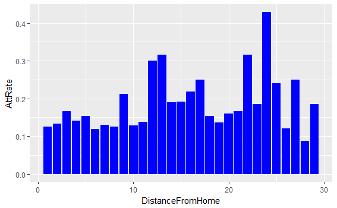

```r
ggplot(attrition_rate_distance) +
  geom_col(mapping = aes(x = DistanceFromHome, y = AttRate), fill = "blue")
```

Looking at that graph, it appears that there are some extremely high attrition rates for some distances, and the general pattern is, that, as the distance increases, so does the attrition rate.

Now, let’s look at education:

```r
attrition_rate_education <- df %>%
  group_by(Education) %>%
  count(att_count = Attrition) %>%
  group_by(att_count)

attrition_rate_true <- attrition_rate_education[attrition_rate_education$att_count,]
attrition_rate_false <- attrition_rate_education[!attrition_rate_education$att_count,]
head(attrition_rate_true)
```

| Education | att_count | n |
| --- | --- | --- |
| 1 | TRUE | 31 |
| 2 | TRUE | 44 |
| 3 | TRUE | 99 |
| 4 | TRUE | 58 |
| 5 | TRUE | 5 |

```r
head(attrition_rate_false)
```

| Education | att_count | n |
| --- | --- | --- |
| 1 | FALSE | 139 |
| 2 | FALSE | 238 |
| 3 | FALSE | 473 |
| 4 | FALSE | 340 |
| 5 | FALSE | 43 |

```r
attrition_rate_education <- merge(attrition_rate_true, attrition_rate_false, by = "Education")
attrition_rate_education <- attrition_rate_education %>%
  mutate(AttRate = n.x / (n.x + n.y))
attrition_rate_education
```

| Education | att_count.x | n.x | att_count.y | n.y | AttRate |
| --- | --- | --- | --- | --- | --- |
| 1 | TRUE | 31 | FALSE | 139 | 0.1823529 |
| 2 | TRUE | 44 | FALSE | 238 | 0.1560284 |
| 3 | TRUE | 99 | FALSE | 473 | 0.1730769 |
| 4 | TRUE | 58 | FALSE | 340 | 0.1457286 |
| 5 | TRUE | 5 | FALSE | 43 | 0.1041667 |

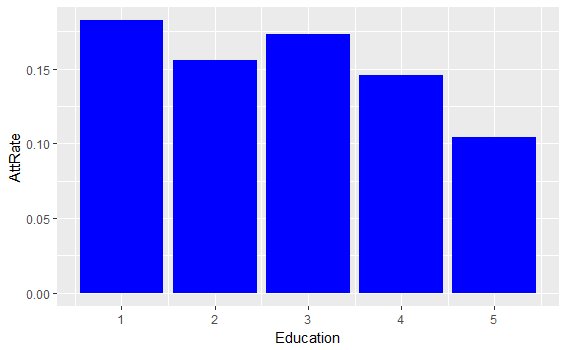

```r
ggplot(attrition_rate_education) +
  geom_col(mapping = aes(x = Education, y = AttRate), fill = "blue")
```

Education appears to relate to attrition too, an increase in education sees a lower rate of attrition. However, nothing is extremely high, and education might be due to a secondary influence.

Let’s continue and create a function to do this analysis:

```r
att_rate <- function(df, grouper) {
  attrition_rate_grouped <- df %>%
    group_by_(grouper) %>%
    count(att_count = Attrition) %>%
    group_by(att_count)

  attrition_rate_true <- attrition_rate_grouped[attrition_rate_grouped$att_count,]
  attrition_rate_false <- attrition_rate_grouped[!attrition_rate_grouped$att_count,]
  attrition_rate_grouped <- merge(attrition_rate_true, attrition_rate_false, by = grouper)
  attrition_rate_grouped <- attrition_rate_grouped %>%
     mutate(AttRate = n.x / (n.x + n.y))
  attrition_rate_grouped
}
# Just test it out to make sure it works
education <- att_rate(df, "Education")
head(education)
```

|  | Education | att_count.x | n.x | att_count.y | n.y | AttRate |
| --- | --- | --- | --- | --- | --- | --- |
| 1 | 1 | TRUE | 31 | FALSE | 139 | 0.1823529 |
| 2 | 2 | TRUE | 44 | FALSE | 238 | 0.1560284 |
| 3 | 3 | TRUE | 99 | FALSE | 473 | 0.1730769 |
| 4 | 4 | TRUE | 58 | FALSE | 340 | 0.1457286 |
| 5 | 5 | TRUE | 5 | FALSE | 43 | 0.1041667 |

```r
names(df)
```

```
 [1] "Age"                      "Attrition"
 [3] "BusinessTravel"           "DailyRate"
 [5] "Department"               "DistanceFromHome"
 [7] "Education"                "EducationField"
 [9] "EmployeeCount"            "EmployeeNumber"
[11] "EnvironmentSatisfaction"  "Gender"
[13] "HourlyRate"               "JobInvolvement"
[15] "JobLevel"                 "JobRole"
[17] "JobSatisfaction"          "MaritalStatus"
[19] "MonthlyIncome"            "MonthlyRate"
[21] "NumCompaniesWorked"       "Over18"
[23] "OverTime"                 "PercentSalaryHike"
[25] "PerformanceRating"        "RelationshipSatisfaction"
[27] "StandardHours"            "StockOptionLevel"
[29] "TotalWorkingYears"        "TrainingTimesLastYear"
[31] "WorkLifeBalance"          "YearsAtCompany"
[33] "YearsInCurrentRole"       "YearsSinceLastPromotion"
[35] "YearsWithCurrManager"
```

Here are just a few more examples:

```r
hourly_att <- att_rate(df, "HourlyRate")
head(hourly_att)
```

|  | HourlyRate | att_count.x | n.x | att_count.y | n.y | AttRate |
| --- | --- | --- | --- | --- | --- | --- |
| 1 | 31 | TRUE | 2 | FALSE | 13 | 0.13333333 |
| 2 | 32 | TRUE | 4 | FALSE | 20 | 0.16666667 |
| 3 | 33 | TRUE | 3 | FALSE | 16 | 0.15789474 |
| 4 | 34 | TRUE | 5 | FALSE | 7 | 0.41666667 |
| 5 | 35 | TRUE | 1 | FALSE | 17 | 0.05555556 |
| 6 | 36 | TRUE | 5 | FALSE | 13 | 0.27777778 |

```r
role_att <- att_rate(df, "JobRole")
head(role_att)
```

|  | JobRole | att_count.x | n.x | att_count.y | n.y | AttRate |
| --- | --- | --- | --- | --- | --- | --- |
| 1 | Healthcare Representative | TRUE | 9 | FALSE | 122 | 0.06870229 |
| 2 | Human Resources | TRUE | 12 | FALSE | 40 | 0.23076923 |
| 3 | Laboratory Technician | TRUE | 62 | FALSE | 197 | 0.23938224 |
| 4 | Manager | TRUE | 5 | FALSE | 97 | 0.04901961 |
| 5 | Manufacturing Director | TRUE | 10 | FALSE | 135 | 0.06896552 |
| 6 | Research Director | TRUE | 2 | FALSE | 78 | 0.02500000 |

```r
performance_att <- att_rate(df, "PerformanceRating")
performance_att
```

| PerformanceRating | att_count.x | n.x | att_count.y | n.y | AttRate |
| --- | --- | --- | --- | --- | --- |
| 3 | TRUE | 200 | FALSE | 1044 | 0.1607717 |
| 4 | TRUE | 37 | FALSE | 189 | 0.1637168 |

We can rule out performance rating, since it has so few variables it would be impossible to interpret.

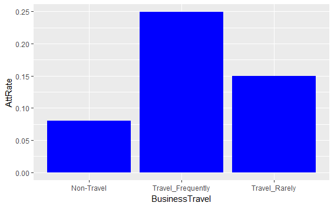

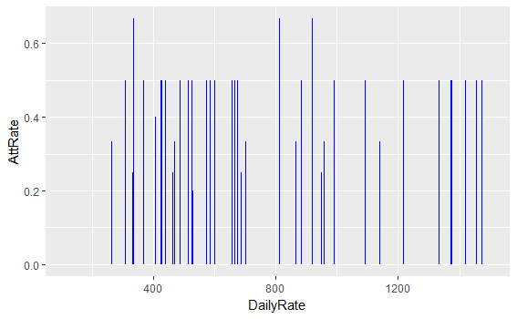

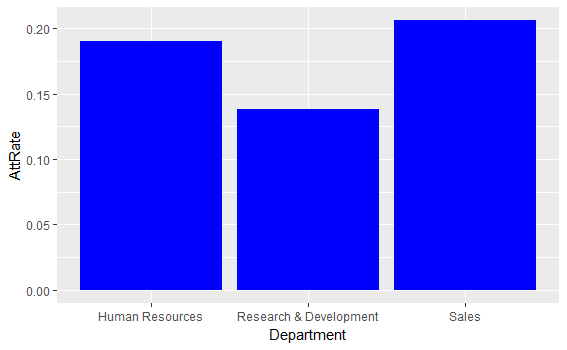

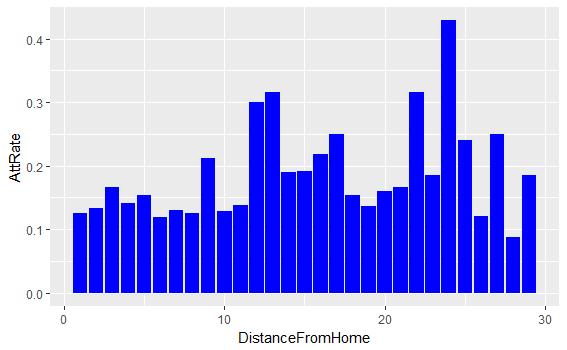

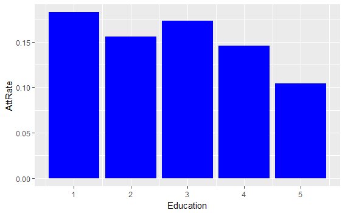

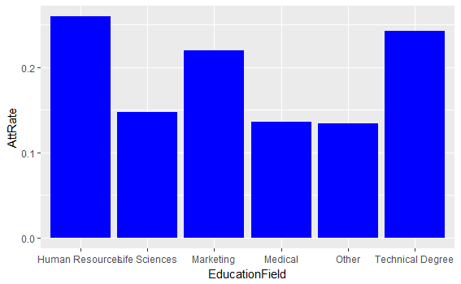

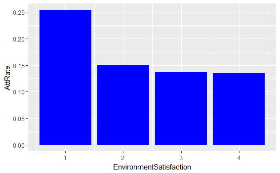

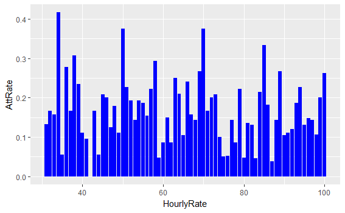

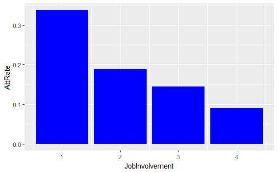

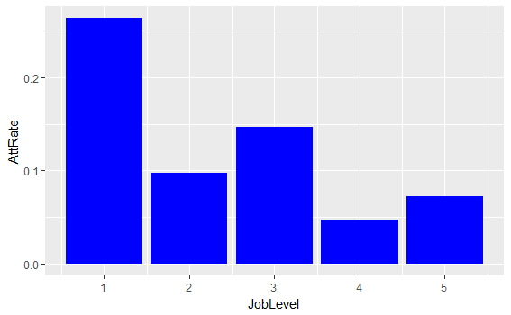

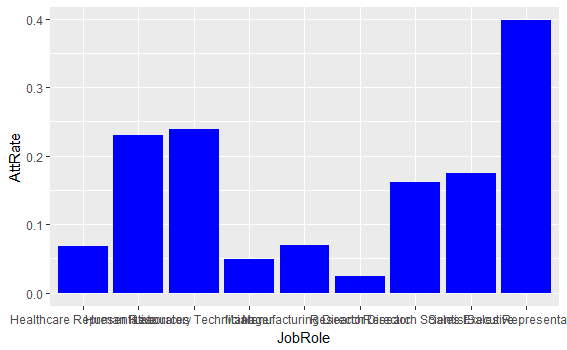

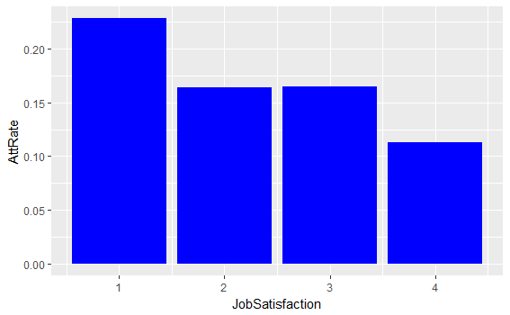

[16 more figures not shown]

```r
exclude_names <- c("Age", "Gender", "Attrition", "Over18", "EmployeeNumber", "EmployeeCount", "StandardHours")
names_use <- names(df)[!names(df) %in% exclude_names]
att_differences <- c()
for (name in names_use) {
  name_att <- att_rate(df, name)
  max_att <- max(name_att$AttRate)
  min_att <- min(name_att$AttRate)
  att_diff <- max_att - min_att
  att_differences <- c(att_differences, att_diff)
  plot <- ggplot(name_att) +
    geom_col(mapping = aes_string(x = name, y = "AttRate"), fill = "blue")
  print(plot)
}
```

```r
att_differences
```

```
 [1] 0.16909747 0.46666667 0.06788052 0.34161491 0.07818627
 [6] 0.12511292 0.11899198 0.37820513 0.24707162 0.21618194
[11] 0.37259036 0.11508394 0.15440172 0.41666667 0.33333333
[16] 0.15333932 0.20092414 0.23015873 0.00294511 0.05837359
[21] 0.16810769 0.46441540 0.18547009 0.17028275 0.46296296
[26] 0.27140255 0.19084967 0.35454545
```

Looking at time based data points (such as years in a job, etc. ), there is an interesting pattern that emerges. The number of years someone has been doing something tends to correlate with a decrease in attrition. However, at highest amount of years, there tends to be an increase. This may, however be due to retirement.

Other interesting patterns:

#### Sales

In the graph of positions, the sales representative postion has a very high attrition rate (near 40%), as well as the sales department having a high attrition rate (21%) compared to other departments.

#### Role Involvement

Steps to improve an employees sense of belonging in a particular position tend to decrease attrition. For example, there is a negative correlation between training times in the last year and attrition rate. And job involvement ratings show a dramatic decrease in attrition (1 = 34%, and the max 4 = 9%)

#### Money Matters

Stock options tend to decrease attrition, however, the highest sees a spike in attrition again. This might be an indication that those with the best stock options tend to be highly desirable employees and thus are at a greater risk of being offered a higher paying position.

#### Misc

Being a manager is appealing: managers have a very low attrition rate (5%), but not quite as appealing as being a research director (2%). Research director positions are so rare, however that it might be more difficult to transfer to another organization with a similar role.

## Chi-Squared Test for Independence

Now that we’ve looked at the graphs, we can start taking a look at what values are related to attrition with a statistical method.

```r
significant_variables <- c()
df <- data.frame(unclass(df))
for (name in names_use) {
  tbl <- table(df[, "Attrition"], df[, name])
  print(name)
  test_result <- chisq.test(tbl)
  if (test_result$p.value < .05) {
    print(test_result)
    significant_variables <- c(significant_variables, name)
  } else {
    print(test_result$p.value)
    print("Did not pass threshold")
  }
}
```

```
[1] "BusinessTravel"

    Pearson's Chi-squared test

data:  tbl
X-squared = 24.182, df = 2, p-value = 5.609e-06

[1] "DailyRate"
```

```
Chi-squared approximation may be incorrect
```

```
[1] 0.62028
[1] "Did not pass threshold"
[1] "Department"

    Pearson's Chi-squared test

data:  tbl
X-squared = 10.796, df = 2, p-value = 0.004526

[1] "DistanceFromHome"
```

```
Chi-squared approximation may be incorrect
```

```
[1] 0.09525314
[1] "Did not pass threshold"
[1] "Education"
[1] 0.5455253
[1] "Did not pass threshold"
[1] "EducationField"
```

```
Chi-squared approximation may be incorrect
```

```
    Pearson's Chi-squared test

data:  tbl
X-squared = 16.025, df = 5, p-value = 0.006774

[1] "EnvironmentSatisfaction"

    Pearson's Chi-squared test

data:  tbl
X-squared = 22.504, df = 3, p-value = 5.123e-05

[1] "HourlyRate"
```

```
Chi-squared approximation may be incorrect
```

```
[1] 0.4105697
[1] "Did not pass threshold"
[1] "JobInvolvement"

    Pearson's Chi-squared test

data:  tbl
X-squared = 28.492, df = 3, p-value = 2.863e-06

[1] "JobLevel"

    Pearson's Chi-squared test

data:  tbl
X-squared = 72.529, df = 4, p-value = 6.635e-15

[1] "JobRole"

    Pearson's Chi-squared test

data:  tbl
X-squared = 86.19, df = 8, p-value = 2.752e-15

[1] "JobSatisfaction"

    Pearson's Chi-squared test

data:  tbl
X-squared = 17.505, df = 3, p-value = 0.0005563

[1] "MaritalStatus"

    Pearson's Chi-squared test

data:  tbl
X-squared = 46.164, df = 2, p-value = 9.456e-11

[1] "MonthlyIncome"
```

```
Chi-squared approximation may be incorrect
```

```
[1] 0.7085811
[1] "Did not pass threshold"
[1] "MonthlyRate"
```

```
Chi-squared approximation may be incorrect
```

```
[1] 0.651263
[1] "Did not pass threshold"
[1] "NumCompaniesWorked"

    Pearson's Chi-squared test

data:  tbl
X-squared = 25.744, df = 9, p-value = 0.002249

[1] "OverTime"

    Pearson's Chi-squared test with Yates' continuity
    correction

data:  tbl
X-squared = 87.564, df = 1, p-value < 2.2e-16

[1] "PercentSalaryHike"
```

```
Chi-squared approximation may be incorrect
```

```
[1] 0.4989552
[1] "Did not pass threshold"
[1] "PerformanceRating"
[1] 0.9900745
[1] "Did not pass threshold"
[1] "RelationshipSatisfaction"
[1] 0.1549724
[1] "Did not pass threshold"
[1] "StockOptionLevel"

    Pearson's Chi-squared test

data:  tbl
X-squared = 60.598, df = 3, p-value = 4.379e-13

[1] "TotalWorkingYears"
```

```
Chi-squared approximation may be incorrect
```

```
    Pearson's Chi-squared test

data:  tbl
X-squared = 122.3, df = 39, p-value = 1.586e-10

[1] "TrainingTimesLastYear"

    Pearson's Chi-squared test

data:  tbl
X-squared = 15.146, df = 6, p-value = 0.01915

[1] "WorkLifeBalance"

    Pearson's Chi-squared test

data:  tbl
X-squared = 16.325, df = 3, p-value = 0.0009726

[1] "YearsAtCompany"
```

```
Chi-squared approximation may be incorrect
```

```
    Pearson's Chi-squared test

data:  tbl
X-squared = 95.389, df = 36, p-value = 2.843e-07

[1] "YearsInCurrentRole"
```

```
Chi-squared approximation may be incorrect
```

```
    Pearson's Chi-squared test

data:  tbl
X-squared = 64.301, df = 18, p-value = 4.056e-07

[1] "YearsSinceLastPromotion"
```

```
Chi-squared approximation may be incorrect
```

```
[1] 0.1119339
[1] "Did not pass threshold"
[1] "YearsWithCurrManager"
```

```
Chi-squared approximation may be incorrect
```

```
    Pearson's Chi-squared test

data:  tbl
X-squared = 74.617, df = 17, p-value = 3.408e-09
```

```r
significant_variables
```

```
 [1] "BusinessTravel"          "Department"
 [3] "EducationField"          "EnvironmentSatisfaction"
 [5] "JobInvolvement"          "JobLevel"
 [7] "JobRole"                 "JobSatisfaction"
 [9] "MaritalStatus"           "NumCompaniesWorked"
[11] "OverTime"                "StockOptionLevel"
[13] "TotalWorkingYears"       "TrainingTimesLastYear"
[15] "WorkLifeBalance"         "YearsAtCompany"
[17] "YearsInCurrentRole"      "YearsWithCurrManager"
```

```r
length(significant_variables)
```

```
[1] 18
```

```r
length(names_use)
```

```
[1] 28
```

#### Differences between attrition rates

```r
attrition_diff_df <- data.frame(names_use, att_differences)
attrition_diff_df
```

| names_use | att_differences |
| --- | --- |
| BusinessTravel | 0.16909747 |
| DailyRate | 0.46666667 |
| Department | 0.06788052 |
| DistanceFromHome | 0.34161491 |
| Education | 0.07818627 |
| EducationField | 0.12511292 |
| EnvironmentSatisfaction | 0.11899198 |
| HourlyRate | 0.37820513 |
| JobInvolvement | 0.24707162 |
| JobLevel | 0.21618194 |

[output cut: 18 more lines]

[output not shown]

[output cut: 18 more lines]